# 社會科學統計方法

資料結構、資料讀取、資料匯出、常用指令(v1.1)

蔡佳泓

2018/3/13

# 1 匯入資料

## 1.1 CSV 資料

RStudio(1.1.423)可以從File–>Import Dataset開啟Text, Excel, SPSS, Stata, SAS等格式的資料。其中Text檔案又分為base以及rdr，前者比較容易，後者則需要用到套件，但是可以控制分隔符號，大致上效果一樣。  
如果要用語法。首先，`R`可以讀取用csv格式儲存的資料，例如：

```r
setwd("~/Library/Mobile Documents/com~apple~CloudDocs/eastasia")
csv1<-read.csv("councilor.csv", header=TRUE, sep=",", fileEncoding = 'BIG5')
head(csv1)
```

```
##   Year budget       unit contracter open
## 1 2015    676     水利處       台球  Yes
## 2 2016    673 新建工程處       茂盛  Yes
## 3 2016    270 新建工程處       冠君  Yes
## 4 2016    255 新建工程處       金煌  Yes
## 5 2016    235 新建工程處       聖鋒  Yes
## 6 2016    190 新建工程處       福呈   No
```

這筆台北市中山區的陳炳甫議員的議員配合款部分資料來自於[議員投票指南](https://councils.g0v.tw)  
指令中的`header=TRUE`表示第一列被認為是變數名稱，而`sep`規範分隔的符號，`fileEncoding=BIG5`則是將文字編碼為中文。 `R`讓使用者控制資料中的字串是否視為因素資料，也就是用`stringAsFactors`控制：

```r
setwd("~/Library/Mobile Documents/com~apple~CloudDocs/eastasia")
csv2<-read.csv("councilor.csv", header=TRUE, sep=",", fileEncoding = 'BIG5', stringsAsFactors = F)
```

比較資料中的變數屬性，請輸入

```r
class(csv1$unit)
```

```
## [1] "factor"
```

```r
class(csv2$unit)
```

```
## [1] "character"
```

字串可以轉換成數字，但是因素無法轉換成數字。  
因為資料裡面的中文常常無法顯示在圖形。請先輸入以下兩行指令列出目前可以使用的字體：  
install.packages(‘extrafont’); library(extrafont)  
font_import(); fonts()

然後選擇其中的中文字型，例如明體，即可顯示中文字型於圖形中：

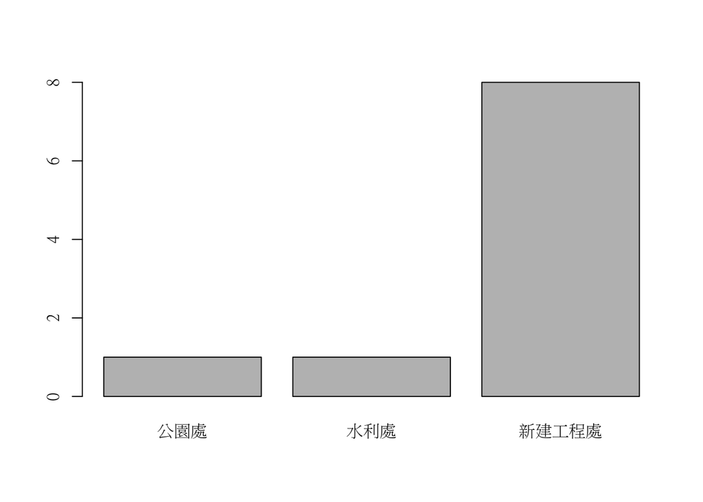

```r
par(family='MingLiU');
barplot(table(csv1$unit))
```

或者選擇其他中文字型，例如粗明體，利用`ggplot2`的繪圖功能：

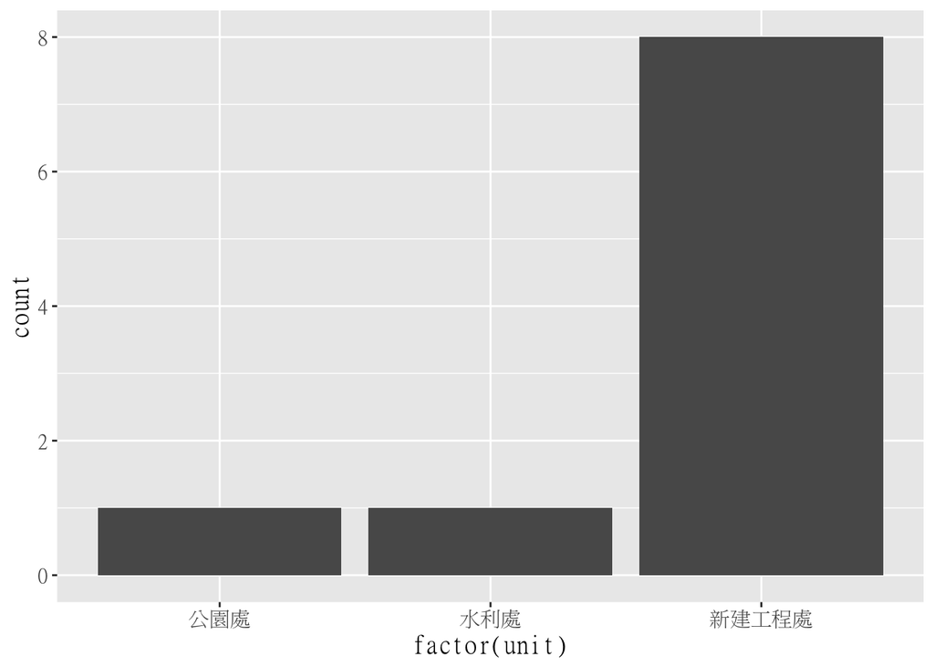

```r
library(ggplot2)
p<-ggplot(data=csv1, aes(x=factor(unit))) +
  geom_bar(stat="count") +
  theme(text=element_text(family="MingLiU", size=14))
p
```

## 1.2 文字資料(txt)

`read.table()`可以讀取用txt格式儲存的表格資料，該資料的欄位用空白區隔，例如：

```r
setwd("~/Library/Mobile Documents/com~apple~CloudDocs/eastasia")
students<-read.table("Studentsfull.txt", header=TRUE, sep="")
head(students)
```

```
##         ID     Name Department Score Gender
## 1 10322011    Ariel  Aerospace    78      F
## 2 10325023    Becky    Physics    86      F
## 3 10430101     Carl Journalism    69      M
## 4 10401032  Dimitri    English    83      M
## 5 10307120  Enrique  Chemistry    80      M
## 6 10207005 Fernando  Chemistry    66      M
```

`scan()`可以讀取向量型態的外部資料，但是無法讀取表格，是一個處理簡單資料的指令，首先以數值資料舉例：

```r
scan('voteshare', comment.char = '#', dec='.')
```

```
##  [1] 55.6 66.1 36.8 65.1 50.9 44.9 48.7 52.4 48.5 53.0 51.9
```

其次以字串與數值資料舉例：

```r
scan('latticegraph', what=c('',''), comment.char = '#', sep=',')
```

```
##  [1] "barchart"    "bwplot"      "cloud"       "contourplot" "densityplot"
##  [6] "dotplot"     "histogram"   "levelplot"   "parallel"    "splom"
## [11] "stripplot"   "xyplot"      "wireframe"   "1"           "1"
## [16] "3"           "3"           "2"           "1"           "1"
## [21] "2"           "4"           "4"           "2"           "2"
## [26] "3"
```

從以上例子可以看出，`scan()`的功能比較簡單，而`read.table()`或是`read.csv()`的功能比較完備。

## 1.3 統計資料

### 1.3.1 Stata

Stata本身可以儲存資料為csv檔或其他檔案，但是`R`有套件可以直接讀取。Stata的12版以前資料則可以用`foreign`這個套件。例如UCLA的[Institue for Digital Research and Education（idre）](https://stats.idre.ucla.edu)的資料：

```r
library(foreign)
udata1<-read.dta("https://stats.idre.ucla.edu/stat/data/test.dta")
head(udata1)
```

```
##    make   model mpg weight price
## 1   AMC Concord  22   2930  4099
## 2   AMC   Pacer  17   3350  4749
## 3   AMC  Spirit  22   2640  3799
## 4 Buick Century  20   3250  4816
## 5 Buick Electra  15   4080  7827
```

如果讀取Stata 的13版以後的資料需要`readstata13`這個套件：

```r
library(readstata13)
udata2<-read.dta13("Mystata.dta")
head(udata2)
```

```
##   Q1 Q2 Q3 Q4 Q5 SEX AGE EDU TOWNID AREAR SENGI T_Cidentity     partyid
## 1  0  1  1  2  2   2   2   5   6305     1     2           1         DPP
## 2  0  1  1  2  3   2   4   3   6608     4     3           2 Independent
## 3 12  2  1  1  2   1   5   2   6302     1     2           1         KMT
## 4  1  2  1  3  2   2   5   3    911     5     2           1         KMT
## 5  0  2  1  1  2   1   4   3    904     5     2           3         KMT
## 6  0  2  1  4  2   2   4   3   6628     4     2           3         KMT
##   PARTY tondu tondu3 peace visit experience tondu3_new consensus
## 1     5     3      2     8     0          1          1         2
## 2    99     4      2     4     0          1          1         4
## 3     2     2      1     5    12          0          2         4
## 4     3     4      2     4     1          0          1         3
## 5     2     4      2     4     0          0          1         4
## 6     2     2      1     6     0          0          2         3
```

`convert.factors`這個參數控制是否將變數的值轉為因素，如果不轉為因素，則維持為整數或者數值。

```r
udata3<-read.dta13("Mystata.dta", convert.factors=F)
class(udata2$partyid); class(udata3$partyid)
```

```
## [1] "factor"
```

```
## [1] "integer"
```

```r
table(udata2$partyid)
```

```
##
##         KMT         DPP          NP         PFP         TSU         NPP
##         287         246           4          21           2          54
## Independent          DK
##         557          73
```

### 1.3.2 SPSS

`foreign`的套件也可以讀取SPSS的資料：

```r
library(foreign)
setwd("~/Library/Mobile Documents/com~apple~CloudDocs/eastasia")
dv<-read.spss('PP0797B2.sav', use.value.labels=F, to.data.frame=TRUE)
table(dv$Q1)
```

```
##
##   1   2   3   4  95  96  97  98
## 617 684 443  91  10  57  52 104
```

程式中 use.value.labels=F表示讀取資料時並不會使用資料中原有的變數標記，例如低、中、高教育程度會變成 1、2、3。這樣做的好處是不必把類別變數轉換成數字，壞處則是需要對照原有的資料才能得知每一個值的意義。如果沒有設定 to.data.frame=T，讀取的資料會轉換成列表。請嘗試去掉use.value.labels=F，也就是`read.spss()`的內建值。  
另一個讀取 SPSS 資料的方法是先下載`memisc`這個套件：

```r
library(memisc)
udata4<-as.data.set(spss.system.file('pp0797B2.sav'))
udata4[1:4, 1:5]
```

```
##
## Data set with 4 observations and 5 variables
##
##           q1       q2         q3       q4     q5
## 1     很難說     同意     不同意     同意   同意
## 2 非常不同意 非常同意     不同意     同意 很難說
## 3 非常不同意 非常同意 非常不同意 非常同意   同意
## 4       同意     同意     不同意     同意 不同意
```

## 1.4 網路連結資料

`R`可以讀取網路的連結資料，讓使用者方便下載分析。例如[idre](https://stats.idre.ucla.edu)的資料：

```r
test.missing <- read.table("https://stats.idre.ucla.edu/stat/data/test_missing_comma.txt",
    header = TRUE, sep = ",")
head(test.missing)
```

```
##     prgtype gender  id ses schtyp level
## 1   general      0  70   4      1     1
## 2    vocati      1 121   4     NA     1
## 3   general      0  86  NA     NA     1
## 4    vocati      0 141   4      3     1
## 5  academic      0 172   4      2     1
## 6  academic      0 113   4      2     1
```

也請到[DSP資料中心](http://data.dsp.im)的資料集找尋感興趣的資料，例如[美元匯率](http://data.dsp.im/dataset/20e67a67-61a5-40db-a788-14bb02a3591b/resource/d68c5762-8321-49bf-8102-23c38ee3c50b/download/.csv)，請問有幾筆匯率的資料？

# 2 資料匯出

`write.table()`可以匯出資料成為txt或是csv格式到指定的目錄，例如載入一個現有的檔案：

```r
setwd("~/Library/Mobile Documents/com~apple~CloudDocs/eastasia")
vs<-scan('voteshare', comment.char = '#', dec='.')
vs
```

```
##  [1] 55.6 66.1 36.8 65.1 50.9 44.9 48.7 52.4 48.5 53.0 51.9
```

增加新的觀察值在vs資料中，然後匯出資料成為txt檔：

```r
scan('voteshare', comment.char = '#', dec='.')
```

```
##  [1] 55.6 66.1 36.8 65.1 50.9 44.9 48.7 52.4 48.5 53.0 51.9
```

```r
vsnew<-c(vs, 61.9, 31.8, 44.5)
vsnew
```

```
##  [1] 55.6 66.1 36.8 65.1 50.9 44.9 48.7 52.4 48.5 53.0 51.9 61.9 31.8 44.5
```

```r
write.table(vsnew,'vsnew.txt')
read.table('vsnew.txt')
```

```
##       x
## 1  55.6
## 2  66.1
## 3  36.8
## 4  65.1
## 5  50.9
## 6  44.9
## 7  48.7
## 8  52.4
## 9  48.5
## 10 53.0
## 11 51.9
## 12 61.9
## 13 31.8
## 14 44.5
```

或者合併資料，並匯出資料為csv檔：

```r
de<-data.frame(name=state.abb, region=state.region, area=state.area)
head(de)
```

```
##   name region   area
## 1   AL  South  51609
## 2   AK   West 589757
## 3   AZ   West 113909
## 4   AR  South  53104
## 5   CA   West 158693
## 6   CO   West 104247
```

```r
write.csv(de, 'state.csv')
state<-read.csv('state.csv', header=TRUE)
head(state)
```

```
##   X name region   area
## 1 1   AL  South  51609
## 2 2   AK   West 589757
## 3 3   AZ   West 113909
## 4 4   AR  South  53104
## 5 5   CA   West 158693
## 6 6   CO   West 104247
```

在合併變數成為一個資料框時，最好給定每一個欄位一個變數名稱，以方便日後分析。而在執行`write.csv()`時，不需要指定分隔的符號，在重新讀取時，也不需要刻意指定，仍然可以匯入正確的資料。

# 3 常用指令

## 3.1 管理環境空間

`R`有 global 這個環境空間中儲存命令列中所建立的任何變數，若要了解 global 環境空間有哪些物件，可以使用`globalenv()` 這個函數，：

```r
globalenv()
```

```
## <environment: R_GlobalEnv>
```

```r
ls(envir = globalenv(),10)
```

```
##  [1] "csv1"         "csv2"         "de"           "df"
##  [5] "dv"           "p"            "state"        "students"
##  [9] "test.missing" "udata1"       "udata2"       "udata3"
## [13] "udata4"       "vs"           "vsnew"
```

`ls()`指令回傳在特定環境空間內的物件。  
以下介紹與環境空間有關的指令：

- 1. `attach()`：在工作環境中，可以把資料框、向量附加到搜尋的路徑，使得變數對`R`是直接可見的。但是attach無法儲存更改後的資料，因此要記得匯出資料，或者是用語法紀錄。例如：

```r
head(csv2)
```

```
##   Year budget       unit contracter open
## 1 2015    676     水利處       台球  Yes
## 2 2016    673 新建工程處       茂盛  Yes
## 3 2016    270 新建工程處       冠君  Yes
## 4 2016    255 新建工程處       金煌  Yes
## 5 2016    235 新建工程處       聖鋒  Yes
## 6 2016    190 新建工程處       福呈   No
```

```r
attach(csv2)
contracter
```

```
##  [1] "台球"   "茂盛"   "冠君"   "金煌"   "聖鋒"   "福呈"   "盛吉"
##  [8] "茂盛"   "冠君"   "未發包"
```

```r
contracter[1]<-"未發包"
csv2$contracter[10]<-"台球"
csv2
```

```
##    Year budget       unit contracter open
## 1  2015    676     水利處       台球  Yes
## 2  2016    673 新建工程處       茂盛  Yes
## 3  2016    270 新建工程處       冠君  Yes
## 4  2016    255 新建工程處       金煌  Yes
## 5  2016    235 新建工程處       聖鋒  Yes
## 6  2016    190 新建工程處       福呈   No
## 7  2015    155     公園處       盛吉  Yes
## 8  2016    154 新建工程處       茂盛  Yes
## 9  2016    142 新建工程處       冠君  Yes
## 10 2016    123 新建工程處       台球  Yes
```

```r
detach(csv2)
csv2
```

```
##    Year budget       unit contracter open
## 1  2015    676     水利處       台球  Yes
## 2  2016    673 新建工程處       茂盛  Yes
## 3  2016    270 新建工程處       冠君  Yes
## 4  2016    255 新建工程處       金煌  Yes
## 5  2016    235 新建工程處       聖鋒  Yes
## 6  2016    190 新建工程處       福呈   No
## 7  2015    155     公園處       盛吉  Yes
## 8  2016    154 新建工程處       茂盛  Yes
## 9  2016    142 新建工程處       冠君  Yes
## 10 2016    123 新建工程處       台球  Yes
```

上面的例子顯示，如果只是更改向量的元素，而不是更改資料框加上向量的元素，那麼並不會真正改變資料框的內容，而一旦更動，即使`detach()`該資料集，也會維持其變動。

- 2. `detach()`：從工作環境移除已經附加的資料框、向量，以避免混淆。
- 3. `rm(list=ls())`：從工作環境移除所有的向量、列表、資料框等等。
- 4. `rm()`：刪除特定的向量、列表、資料框等等。
- 5. `save.image()`：儲存環境空間內所有的資料與結果。
- 6. `load()`：下載所有資料與結果。

```r
rm(list=ls()) #remove all data
data(mtcars) #suppose we analyze mtcars
m1<-lm(mpg ~ cyl, data=mtcars) #regression
summary(m1) #results
```

```
##
## Call:
## lm(formula = mpg ~ cyl, data = mtcars)
##
## Residuals:
##     Min      1Q  Median      3Q     Max
## -4.9814 -2.1185  0.2217  1.0717  7.5186
##
## Coefficients:
##             Estimate Std. Error t value Pr(>|t|)
## (Intercept)  37.8846     2.0738   18.27  < 2e-16 ***
## cyl          -2.8758     0.3224   -8.92 6.11e-10 ***
## ---
## Signif. codes:  0 '***' 0.001 '**' 0.01 '*' 0.05 '.' 0.1 ' ' 1
##
## Residual standard error: 3.206 on 30 degrees of freedom
## Multiple R-squared:  0.7262, Adjusted R-squared:  0.7171
## F-statistic: 79.56 on 1 and 30 DF,  p-value: 6.113e-10
```

```r
mydata<-data.frame(date=as.Date(c("2018-03-13","2018-03-14","2018-03-15"), format='%Y-%m-%d'), workinghours=c(4, 3, 4)) #create your own data
setwd("~/Library/Mobile Documents/com~apple~CloudDocs/eastasia") #working directory
save.image("test.Rdata") #save all results to Rdata
rm(list=ls()) #remove all data
load("test.Rdata") #load Rdata
ls(envir = globalenv(),10) #display objects in this environment
```

```
## [1] "m1"     "mtcars" "mydata"
```

```r
mydata #diplay your data
```

```
##         date workinghours
## 1 2018-03-13            4
## 2 2018-03-14            3
## 3 2018-03-15            4
```

- 7. `saveRds()`：儲存成RDS  
     如果只有單一的物件，可以考慮`saveRDS()`。如果不想儲存原來的物件名稱，也可以考慮`saveRDS()`。

```r
setwd("~/Library/Mobile Documents/com~apple~CloudDocs/eastasia")
vs<-scan('voteshare', comment.char = '#', dec='.')
vs
```

```
##  [1] 55.6 66.1 36.8 65.1 50.9 44.9 48.7 52.4 48.5 53.0 51.9
```

```r
vs2<-vs/100
saveRDS(vs, "vs.rds")
saveRDS(vs2, 'vs2.rds')
rm(vs); rm(vs2)
vs<-readRDS('vs.rds')
vs2<-readRDS('vs2.rds')
vs; vs2
```

```
##  [1] 55.6 66.1 36.8 65.1 50.9 44.9 48.7 52.4 48.5 53.0 51.9
```

```
##  [1] 0.556 0.661 0.368 0.651 0.509 0.449 0.487 0.524 0.485 0.530 0.519
```

`saveRDS()`的優點是雖然一次只儲存一個物件，但是藉由儲存，可以避免新的物件蓋過舊的物件，新舊物件可以並存。

## 3.2 程式相關

- `cat()`：顯示向量以及運算結果，並可以加上文字，並且用“斜線n”參數換行：

```r
x<-c(2,4,6)
cat(x, "\n");
```

```
## 2 4 6
```

```r
cat("summation:", sum(x), "\n", "average:", mean(x))
```

```
## summation: 12
##  average: 4
```

- `print()`：顯示資料框、向量、列表等等，但是無法附加上文字。
- `source()`：`R`可以讀取既有指令的檔案，在不必開啟命令稿的情況下直接執行多行程式，可節省許多篇幅以及時間。例如我們寫一個自訂函數，語法很長，我們先存成一個語法檔，未來可以直接執行。

  ```markdown
  sink("twohistograms.R") #define a new script file
  cat("set.seed(02138)") #input a function that sets starting number for random number
  cat("\n") #end of line
  cat("#write R script to a file without opening a document")
  cat("\n")  #end of line
   cat("fnorm<-function(mu){            #create a function with a parameter: mu
    sample.o<-rnorm(20,mu,1/sqrt(mu))  #define the 1st vector that generates random numbers
    sample.i<-sample.o+runif(1,0,10)  #define the 2nd vector that generates random numbers
    par(mfrow=c(1,2))                 #set parameter of graphic for 1*2 graphics
    hist(sample.o, col=1, main='',    #histogram with Basic R
              xlab='Original sample')
           hist(sample.i, col=4, main='', #another histogram
            xlab='Original sample + random number')
    }")
   cat("\n")  #end of function
   sink()     #save the script in the specified file
  file.show("twohistograms.R") #Opening an editor to show the script
  ```

  我們建立 fnorm()這個函數，並且存成一個語法檔(“twohistograms.R”)，並且用`file.show()`顯示出來。以後就可以執行它。  
  使用`source()`函數，執行“twohistograms.R”此一語法檔，產生一個自訂函數，然後輸入參數便可顯示結果。請執行上面的指令之後，自行輸入以下兩行語法：

```markdown
source("twohistograms.R")
fnorm(1)
```

如果執行成功會看到以下圖形：

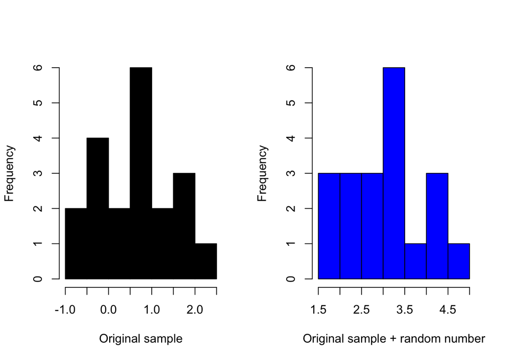

確定一下工作目錄的確多了“twohistograms.R”此一語法檔。

- `with()`：當環境空間有一個以上的資料框，為了避免混淆，可以使用該指令進行分析：

```r
library(car)
```

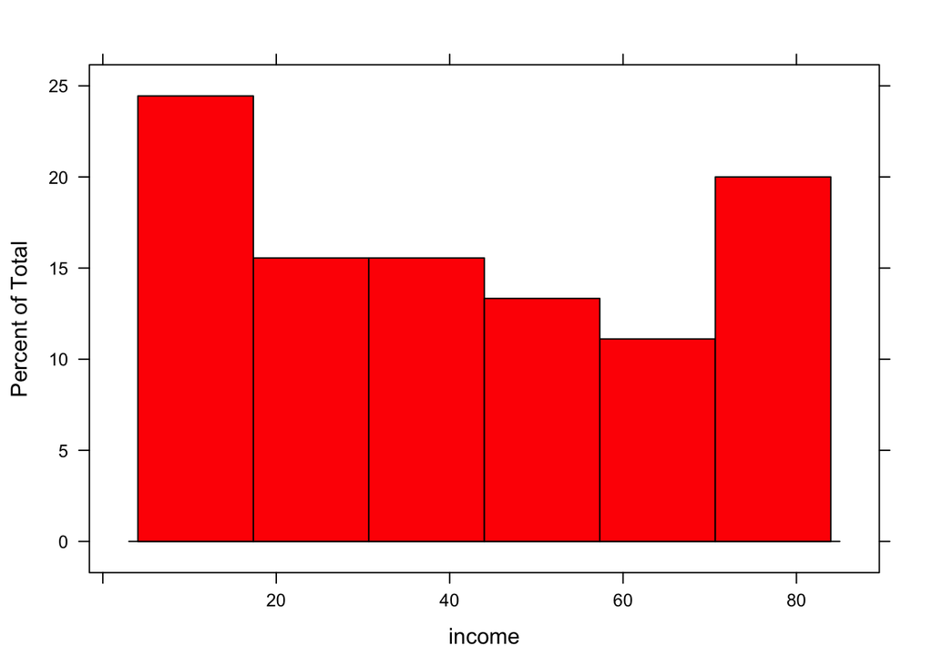

```r
with(Duncan, histogram(income, col=2))
```

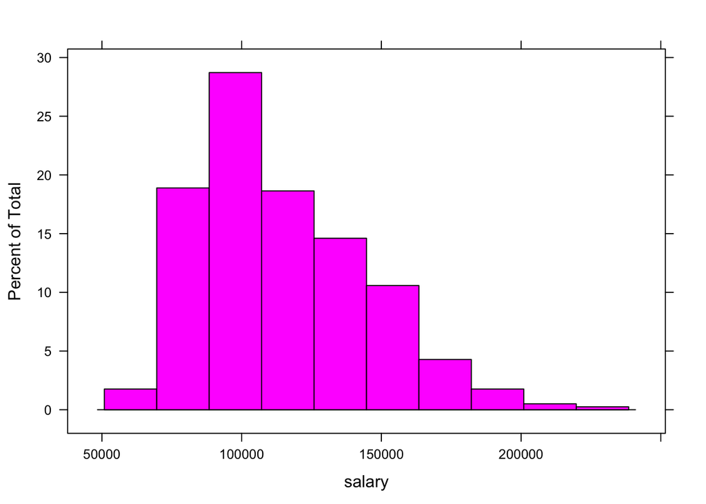

```r
with(Salaries, histogram(salary, col=6))
```

注意，該指令不適用於矩陣，例如state.x77。

## 3.3 資料相關

- `names()`：顯示資料框的變數名稱，例如：

```r
names(mtcars)
```

```
##  [1] "mpg"  "cyl"  "disp" "hp"   "drat" "wt"   "qsec" "vs"   "am"   "gear"
## [11] "carb"
```

注意，該指令不適用於矩陣，例如state.x77。

- `which()`：顯示特定變數。例如，哪些樹的圓周符合條件：

```r
which(Orange$circumference>100)
```

```
##  [1]  4  5  6  7 10 11 12 13 14 18 19 20 21 24 25 26 27 28 32 33 34 35
```

看起來有相當多的樹木胸圍超過100公釐（10公分），但是到底有哪些樹符合這個條件？可應用`which()`函數加以篩選：

```r
oc<-which(Orange$circumference>100) #create a vector of data that meets a condition
oc
```

```
##  [1]  4  5  6  7 10 11 12 13 14 18 19 20 21 24 25 26 27 28 32 33 34 35
```

```r
Orange[oc,] #match data with the vector
```

```
## Grouped Data: circumference ~ age | Tree
##    Tree  age circumference
## 4     1 1004           115
## 5     1 1231           120
## 6     1 1372           142
## 7     1 1582           145
## 10    2  664           111
## 11    2 1004           156
## 12    2 1231           172
## 13    2 1372           203
## 14    2 1582           203
## 18    3 1004           108
## 19    3 1231           115
## 20    3 1372           139
## 21    3 1582           140
## 24    4  664           112
## 25    4 1004           167
## 26    4 1231           179
## 27    4 1372           209
## 28    4 1582           214
## 32    5 1004           125
## 33    5 1231           142
## 34    5 1372           174
## 35    5 1582           177
```

oc是滿足樹的圓周超過100公釐的觀察值，而以該資料框配對這些觀察值，只留下可以配對的每一列觀察值。

- `rep(A, n)`：重複A數值或者字串n次

```r
rep(3, 5)
```

```
## [1] 3 3 3 3 3
```

```r
c(rep("大", 3), rep("中", 1), rep("小",2))
```

```
## [1] "大" "大" "大" "中" "小" "小"
```

- `seq(i,j)`：傳回i到j的連續數字

```r
seq(1,10)
```

```
##  [1]  1  2  3  4  5  6  7  8  9 10
```

```r
seq(100,110, by=2)
```

```
## [1] 100 102 104 106 108 110
```

- `seq(i:j)`：傳回i到j的順位數字

```r
seq(5:10)
```

```
## [1] 1 2 3 4 5 6
```

```r
seq(100:110)
```

```
##  [1]  1  2  3  4  5  6  7  8  9 10 11
```

# 4 作業

1. 請匯入這筆ire的資料hsb2_small(“https://stats.idre.ucla.edu/stat/data/hsb2_small.csv”)，並且顯示該資料的變數名稱。
2. 請使用site=“http://faculty.gvsu.edu/kilburnw/nes2008.RData” 以及load(file=url(site))。由以上指令讀取資料後，請先列出V083097的分佈。然後把這個變數重新編碼為「民主黨」(Democrat)、「共和黨」(Republican)、「獨立」(Independent)、「其他政黨」（Other party (SPECIFY)），然後列出這個變數的次數分配。
3. 請匯出hsb2_small的資料為Text格式以及rds格式。
4. 請匯入2008年的總統選舉資料(2008Election.csv)，並且找出國民黨得票率最高的town.id。（提示：最大值的函數為max()）
5. 請嘗試匯入本週課程所使用的studentsfull檔案，但是這一次用`read.csv()`。